# A Bayesian General Linear Model Approach to Cortical Surface fMRI Data Analysis

A. F. Mejia, Y. Yue, D. Bolin, L. Lindgren, M. A. Lindquist

# Single Subject Bayesian GLM

$$y = \sum_{k=0}^K X_k \beta_k + \sum_{j=1}^J Z_j b_j + \epsilon$$

- $T$: number of scans/timepoints
- $N$: number of vertices
- $K$: number of tasks
- $J$: number of nuisiance parameters
- $y, \epsilon \in \mathbb{R}^{TN}$
- $X_k, Z_k \in \mathbb{R}^{TN \times N}$
- $\beta_k, b_j \in \mathbb{R}^{N}$

# Single Subject Bayesian GLM

$$y = \sum_{k=0}^K X_k \beta_k + \sum_{j=1}^J Z_j b_j + \epsilon$$

- $\epsilon \sim \mathcal{N}(0, V)$
- $V = I_N \otimes \Sigma(\xi, \phi)$,
  - $\Sigma(\xi, \phi)$ covariance matrix for $AR(p)$ process
  - $\xi$ is the marginal precision
  - $\phi \in \mathbb{R}^p$ are partial autocorrelation functions
- $\log \xi = \theta_1 \sim LogGamma(\cdot, \cdot)$
- $\log \frac{1 + \phi_{r-1}}{1 - \phi_{r+1}} = \theta_r$,  
  $\begin{bmatrix} \theta_2 \\ \vdots \\ \theta_{p+1} \end{bmatrix} \sim \mathcal{N}(\cdot, \cdot)$
- $b_j \sim \mathcal{N}(0, \delta I)$

# Stochastic PDE Spatial Priors

Matern Gaussian process for $\beta(u)$:

$$Cov(u, v) = \frac{\sigma^2}{2^{\nu - 1}}
\kappa^\nu ||u - v||^\nu K_\nu (\kappa ||u - v||)$$

- $u, v \in \mathbb{R}^d$
- $K_\nu(\cdot)$: modified Bessel function of the second kind with order $\nu > 0$
- $\nu$: controls smoothness
- $\kappa$: spatial scale
- $\sigma^2 = Var(u) = Cov(u, u)$
- Results in a dense covariance matrix - hard to invert

# Stochastic PDE Spatial Priors

Gaussian Markov Random Field Representation Through Solving SPDE:

$$(\kappa^2 - \nabla_u^2) (\tau \beta(u)) = \mathcal{W}(u)$$

- $\nu = 2 - d / 2$
- $\sigma^2 = \frac{\Gamma(\nu)}{(4 \pi)^{d/2} \kappa^{2 \nu} \tau^2}$
- $\mathcal{W}(u)$: Gaussian white noise process

Gaussian Markov Random Field Representation Through Solving SPDE:

$\beta(u)$ can be approximated using basis expansion:

$$\beta(u) \approx \sum_i^N \psi_i (u) w_i$$

- $N$: number of vertices
- $\phi_i = \begin{cases} 1 & u \text{ at } i^{th} \text{ vertex} \\ 0 & \text{else} \end{cases}$
- $w_i$: weights at each vertex (determined by interpolation)

SPDE prior for $\beta$:

$$\beta = \Psi w$$
$$w \mid \kappa, \tau \sim \mathcal{N}(0, Q_{\kappa, \tau}^{-1})$$

- $Q_{\kappa, \tau} = \tau^2 (\kappa^4 C + 2 \kappa^2 G + G C^{-1} G)$
- $C$: a diagonal matrix
- $G$: graph adjacency matrix

# Stochastic PDE Spatial Priors

$$y \mid \beta_k, b_j, \kappa, \tau \sim \mathcal{N}(\mu_y, V)$$

$$\mu_y = \sum_{k=0}^K X_k \beta_k + \sum_{j=1}^J Z_j b_j$$

$$\beta_k = \Psi_k w_k$$

$$w_k \mid \theta \sim \mathcal{N}(0, Q_{\kappa_k, \tau_k}^{-1})$$

$$b_j \sim \mathcal{N}(0, \delta I)$$

$$\theta \sim \pi(\theta)$$

$\theta = (\xi, \phi_1, ..., \phi_p, \kappa_0, ..., \kappa_K, \tau_0, ..., \tau_K)$

# Posterior Approximation

Goal: Determine $\pi(\beta_0, ..., \beta_K \mid y)$

Typical method: Determine conditional distributions and sample using MCMC  
But this method is too costly for this problem

INLA method

1. Use Laplace approximation for $\pi(\theta | y)$ to obtain $\tilde{\pi}(\theta | y)$
2. Use Laplace approximation to obtain $\tilde{\pi}(f_i | y, \theta_l)$
   - $f = \begin{bmatrix} \beta_0 \\ \vdots \\ \beta_K \\ b_1 \\ \vdots b_J \end{bmatrix}$
3. Approximate $\tilde{\pi}(f_i | y) \approx \sum_l \lambda_l \tilde{\pi}(f_i | y, \theta_l)$
   - $\lambda_l \propto \tilde{\pi}(\theta_l | y)$

# Activation Identification

Typical method:

- For each vertex $u$, compute $p$-value $P(\beta(u) > \gamma_\alpha)$
- Classify vertices where $p$-values are small as active
- Make sure to control for FDR or FWER

Using joint posterior probability maps

1. Let $A_\gamma^+(f) = \{u \in \Omega : f(u) > \gamma\}$, the set of vertices where the estimated value exceeds some threshold $\gamma$
2. Define the positive excursion set $E_{\gamma, \alpha}^+(f) = \arg\max_D \{|D| : P(D \subset A_\gamma^+(f)) \geq 1 - \alpha\}$
   - $\pi(f | y) = \int \pi(f | y, \theta) \pi(\theta | y) d \theta$

# Simulation Study

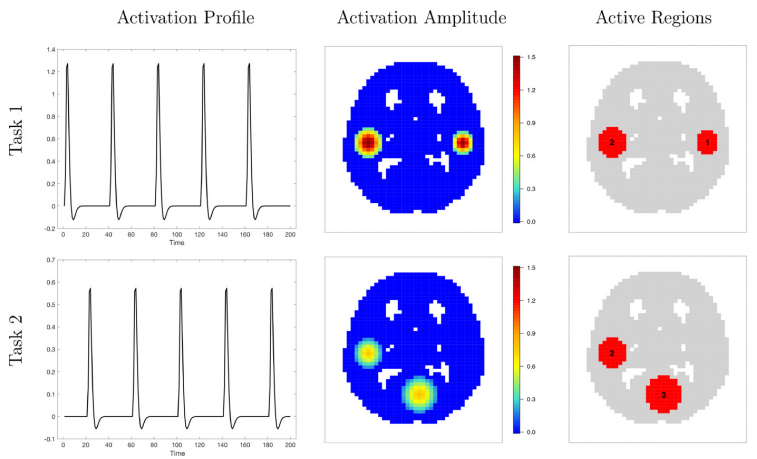

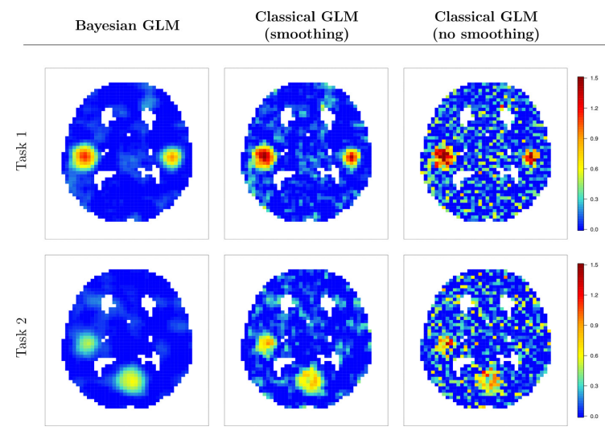

# Simulation Study

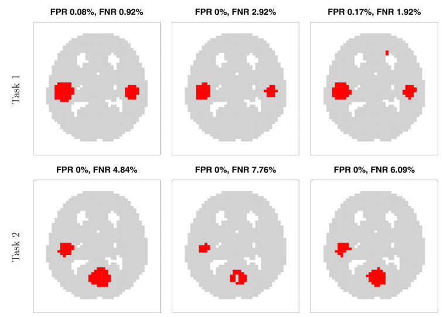

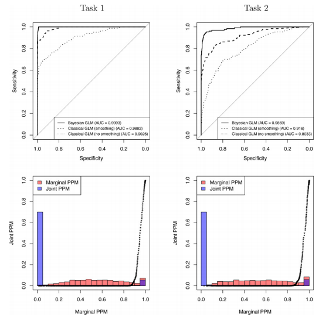

# Experimental Data Results

Data description

- Pre-processed cs-fMRI data from 20 HCP subjects
- Visual, motor, and gambling tasks
- BOLD signal normalized by global signal - responses represent percent change
  - Also removes intercept term
- Removed nuisiance covariates beforehand
- Prewhitening performed assuming AR(6) process
- Each hemisphere resampled to 6000 vertices

Model after preprocessing:

$$y_m = \sum_{k=1}^K X_{mk} \beta_{mk} + e_m$$
$$e_m \sim \mathcal{N}(0, \sigma^2_m I)$$

- $m$ - subject index
- $K = 1$ or $2$ based on task/model
- $y$, $\epsilon$, $X_{mk}$, $\beta_{mk}$ of dimension described in theory part

# Experimental Data Results

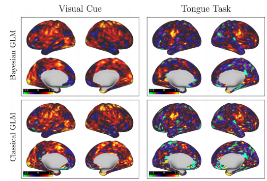